# Bikes

```python
import pandas as pd
import seaborn as sns
import numpy as np
import datetime
import matplotlib.pyplot as plt
import folium
from folium.plugins import HeatMap
%matplotlib inline
```

### 1. Importando os dados

```python
d1 = pd.read_csv('C:/Users/vlcal/Downloads/trips_BikeSSA_2020-01-01_2020-01-31.csv',sep=',')
d2 = pd.read_csv('C:/Users/vlcal/Downloads/trips_BikeSSA_2020-02-01_2020-02-29.csv',sep=',')
d3 = pd.read_csv('C:/Users/vlcal/Downloads/trips_BikeSSA_2020-07-01_2020-07-31.csv',sep=',')
d4 = pd.read_csv('C:/Users/vlcal/Downloads/trips_BikeSSA_2020-03-01_2020-03-31.csv',sep=',')
```

```python
df = pd.concat([d1,d2,d3,d4])
```

#### Visualização do formato

```python
df.head()
```

|  | trip_id | duration_seconds | initial_station_name | start_time | final_station_name | end_time | birth_year |
| --- | --- | --- | --- | --- | --- | --- | --- |
| 0 | 1019234BikeSSA | 2718 | 8 - Quadras do Rio Vermelho | 2020-01-01 05:08:05 | 2 - Estação Porto da Barra | 2020-01-01 05:53:23 | 1984.0 |
| 1 | 1019236BikeSSA | 1426 | 31 - Fonte do Boi | 2020-01-01 05:30:42 | 4 - Orungan | 2020-01-01 05:54:28 | 1993.0 |
| 2 | 1019237BikeSSA | 989 | 33 - Jardim de Alah | 2020-01-01 05:32:47 | 11 - Amaralina | 2020-01-01 05:49:16 | 1997.0 |
| 3 | 1019238BikeSSA | 2020 | 38 - Piatã | 2020-01-01 05:35:36 | 19 - Pinto de Aguiar (UCSAL) | 2020-01-01 06:09:16 | 1995.0 |
| 4 | 1019239BikeSSA | 1984 | 38 - Piatã | 2020-01-01 05:36:35 | 19 - Pinto de Aguiar (UCSAL) | 2020-01-01 06:09:39 | 1993.0 |

### 2. Tratamento de dados

#### Transformando os títulos das colunas / variáveis

Só por questão de organização

```python
df.columns = ['id','duracaoSeg','estacaoInicial','inicioViagem','estacaoFinal', 'terminoViagem', 'anoNasc']
df.head()
```

|  | id | duracaoSeg | estacaoInicial | inicioViagem | estacaoFinal | terminoViagem | anoNasc |
| --- | --- | --- | --- | --- | --- | --- | --- |
| 0 | 1019234BikeSSA | 2718 | 8 - Quadras do Rio Vermelho | 2020-01-01 05:08:05 | 2 - Estação Porto da Barra | 2020-01-01 05:53:23 | 1984.0 |
| 1 | 1019236BikeSSA | 1426 | 31 - Fonte do Boi | 2020-01-01 05:30:42 | 4 - Orungan | 2020-01-01 05:54:28 | 1993.0 |
| 2 | 1019237BikeSSA | 989 | 33 - Jardim de Alah | 2020-01-01 05:32:47 | 11 - Amaralina | 2020-01-01 05:49:16 | 1997.0 |
| 3 | 1019238BikeSSA | 2020 | 38 - Piatã | 2020-01-01 05:35:36 | 19 - Pinto de Aguiar (UCSAL) | 2020-01-01 06:09:16 | 1995.0 |
| 4 | 1019239BikeSSA | 1984 | 38 - Piatã | 2020-01-01 05:36:35 | 19 - Pinto de Aguiar (UCSAL) | 2020-01-01 06:09:39 | 1993.0 |

#### Conhecendo os tipos das colunas / variáveis

```python
df.info()
```

```
<class 'pandas.core.frame.DataFrame'>
Int64Index: 161861 entries, 0 to 37280
Data columns (total 7 columns):
 #   Column          Non-Null Count   Dtype
---  ------          --------------   -----
 0   id              161861 non-null  object
 1   duracaoSeg      161861 non-null  int64
 2   estacaoInicial  161861 non-null  object
 3   inicioViagem    161861 non-null  object
 4   estacaoFinal    161850 non-null  object
 5   terminoViagem   161861 non-null  object
 6   anoNasc         161503 non-null  float64
dtypes: float64(1), int64(1), object(5)
memory usage: 9.9+ MB
```

Temos:

- 1 coluna float (decimal);
- 1 coluna int64 (inteiro);
- 5 colunas objeto.

Estas informações são importantes para saber quais operações podemos fazer com cada coluna.

#### Verificando valores faltantes em cada coluna

```python
df.isnull().sum()
```

```
id                  0
duracaoSeg          0
estacaoInicial      0
inicioViagem        0
estacaoFinal       11
terminoViagem       0
anoNasc           358
dtype: int64
```

Existem 11 linhas sem `estacaoFinal` e 358 linhas sem `anoNasc`. Estes valores precisam ser preenchidos ou eliminados para que não comprometa cálculos ou gráficos, muitos nem funcionam caso existam valores `NaN` (nulos).

Puxando as 11 viagens que não tem registro de estação final:

```python
df[df['estacaoFinal'].isnull()].sort_values('duracaoSeg',ascending=False)
```

|  | id | duracaoSeg | estacaoInicial | inicioViagem | estacaoFinal | terminoViagem | anoNasc |
| --- | --- | --- | --- | --- | --- | --- | --- |
| 35685 | 1063354BikeSSA | 2269579 | 10 - Largo da Mariquita | 2020-01-17 20:44:50 | NaN | 2020-02-13 03:11:09 | 1990.0 |
| 48653 | 1079285BikeSSA | 1155895 | 2 - Estação Porto da Barra | 2020-01-25 10:51:39 | NaN | 2020-02-07 19:56:34 | 1974.0 |
| 44349 | 1151299BikeSSA | 777694 | 2 - Estação Porto da Barra | 2020-02-29 15:06:53 | NaN | 2020-03-09 15:08:27 | 1992.0 |
| 16741 | 1172693BikeSSA | 677309 | 29 - Praça do Sol | 2020-03-11 18:53:30 | NaN | 2020-03-19 15:01:59 | 1972.0 |
| 36917 | 1142069BikeSSA | 505900 | 40 - Imbuí II | 2020-02-21 11:44:40 | NaN | 2020-02-27 08:16:20 | 1997.0 |
| 7718 | 1105800BikeSSA | 429520 | 8 - Quadras do Rio Vermelho | 2020-02-04 20:31:41 | NaN | 2020-02-09 19:50:21 | 1956.0 |
| 18983 | 1175428BikeSSA | 286913 | 39 - Itapuã | 2020-03-13 07:51:08 | NaN | 2020-03-16 15:33:01 | 1997.0 |
| 35801 | 1196627BikeSSA | 67670 | 6 - UFBA Ondina Portão Principal | 2020-03-29 21:20:33 | NaN | 2020-03-30 16:08:23 | 1982.0 |
| 2756 | 1155422BikeSSA | 63632 | 8 - Quadras do Rio Vermelho | 2020-03-02 16:45:59 | NaN | 2020-03-03 10:26:31 | 2002.0 |
| 37270 | 1198565BikeSSA | 51767 | 6 - UFBA Ondina Portão Principal | 2020-03-31 21:32:30 | NaN | 2020-04-01 11:55:17 | 1994.0 |
| 28160 | 1186760BikeSSA | 2172 | 21 - Campo Grande | 2020-03-18 08:47:31 | NaN | 2020-03-18 09:23:43 | 1964.0 |

Das onze que não tem a estação final, dez viagens possuem mais de 14 horas e entregue no dia seguinte. De repente são bikes retiradas para manutenção, registros corrompidos, furtos ou qualquer tipo de eventos fora do padrão.

De qualquer forma, penso que estas 11 viagens deveriam ser retiradas do conjunto de dados.

```python
df = df[df['estacaoFinal'].notnull()]
df.isnull().sum()
```

```
id                  0
duracaoSeg          0
estacaoInicial      0
inicioViagem        0
estacaoFinal        0
terminoViagem       0
anoNasc           358
dtype: int64
```

Dando uma olhada nas 358 viagens com `ano de nascimento`= nulo.

```python
df[df['anoNasc'].isnull()].sort_values('duracaoSeg',ascending=False)
```

|  | id | duracaoSeg | estacaoInicial | inicioViagem | estacaoFinal | terminoViagem | anoNasc |
| --- | --- | --- | --- | --- | --- | --- | --- |
| 7 | 1019242BikeSSA | 21190 | 8 - Quadras do Rio Vermelho | 2020-01-01 05:45:37 | 8 - Quadras do Rio Vermelho | 2020-01-01 11:38:47 | NaN |
| 41339 | 1147669BikeSSA | 12982 | 8 - Quadras do Rio Vermelho | 2020-02-26 17:53:39 | 22 - Largo da Graça | 2020-02-26 21:30:01 | NaN |
| 36849 | 1141960BikeSSA | 11725 | 39 - Itapuã | 2020-02-21 09:59:38 | 38 - Piatã | 2020-02-21 13:15:03 | NaN |
| 17398 | 1173463BikeSSA | 11628 | 8 - Quadras do Rio Vermelho | 2020-03-12 09:23:34 | 3 - Barra Professor Lemos Brito | 2020-03-12 12:37:22 | NaN |
| 5101 | 1025449BikeSSA | 10384 | 2 - Estação Porto da Barra | 2020-01-04 12:19:16 | 36 - Patamares | 2020-01-04 15:12:20 | NaN |
| ... | ... | ... | ... | ... | ... | ... | ... |
| 3844 | 1101095BikeSSA | 119 | 8 - Quadras do Rio Vermelho | 2020-02-02 21:46:34 | 8 - Quadras do Rio Vermelho | 2020-02-02 21:48:33 | NaN |
| 3843 | 1101094BikeSSA | 116 | 8 - Quadras do Rio Vermelho | 2020-02-02 21:46:29 | 8 - Quadras do Rio Vermelho | 2020-02-02 21:48:25 | NaN |
| 44031 | 1150929BikeSSA | 101 | 2 - Estação Porto da Barra | 2020-02-29 08:42:22 | 2 - Estação Porto da Barra | 2020-02-29 08:44:03 | NaN |
| 3845 | 1101096BikeSSA | 82 | 8 - Quadras do Rio Vermelho | 2020-02-02 21:46:41 | 8 - Quadras do Rio Vermelho | 2020-02-02 21:48:03 | NaN |
| 21050 | 1045321BikeSSA | 75 | 10 - Largo da Mariquita | 2020-01-11 11:14:20 | 10 - Largo da Mariquita | 2020-01-11 11:15:35 | NaN |

358 rows × 7 columns

Dúvida que surgiu pra tratar os dados dos `anos de nascimento`:

- O `ID` é unico para cada cliente ou é único para cada viagem?

```python
df.nunique()
```

```
id                161848
duracaoSeg          7706
estacaoInicial        57
inicioViagem      157328
estacaoFinal          61
terminoViagem     154366
anoNasc               98
dtype: int64
```

Existem 161848 valores únicos pro `ID`, dois a menos que a quantidade total de viagens.

Descobrindo quais são os dois `IDs` que não são únicos:

```python
df['id'].value_counts()>1
```

```
1047903BikeSSA     True
1166290BikeSSA     True
1157353BikeSSA    False
1167253BikeSSA    False
1192291BikeSSA    False
                  ...
1176552BikeSSA    False
1023837BikeSSA    False
1134816BikeSSA    False
1257671BikeSSA    False
1073906BikeSSA    False
Name: id, Length: 161848, dtype: bool
```

```python
df[(df['id'] == '1166290BikeSSA') | (df['id'] == '1047903BikeSSA')]
```

|  | id | duracaoSeg | estacaoInicial | inicioViagem | estacaoFinal | terminoViagem | anoNasc |
| --- | --- | --- | --- | --- | --- | --- | --- |
| 23112 | 1047903BikeSSA | 2984 | 11 - Amaralina | 2020-01-12 09:38:53 | 11 - Amaralina | 2020-01-12 10:28:37 | 1996.0 |
| 23113 | 1047903BikeSSA | 2984 | 11 - Amaralina | 2020-01-12 09:38:53 | 11 - Amaralina | 2020-01-12 10:28:37 | 1996.0 |
| 11464 | 1166290BikeSSA | 3728 | 11 - Amaralina | 2020-03-08 09:36:52 | 11 - Amaralina | 2020-03-08 10:39:00 | 1996.0 |
| 11465 | 1166290BikeSSA | 3728 | 11 - Amaralina | 2020-03-08 09:36:52 | 11 - Amaralina | 2020-03-08 10:39:00 | 1996.0 |

De repente algum bug, duas viagens foram registradas duas vezes na mesma hora, minuto e segundo. Será removida uma de cada.

```python
df = df.drop_duplicates()
df.info()
```

```
<class 'pandas.core.frame.DataFrame'>
Int64Index: 161848 entries, 0 to 37280
Data columns (total 7 columns):
 #   Column          Non-Null Count   Dtype
---  ------          --------------   -----
 0   id              161848 non-null  object
 1   duracaoSeg      161848 non-null  int64
 2   estacaoInicial  161848 non-null  object
 3   inicioViagem    161848 non-null  object
 4   estacaoFinal    161848 non-null  object
 5   terminoViagem   161848 non-null  object
 6   anoNasc         161490 non-null  float64
dtypes: float64(1), int64(1), object(5)
memory usage: 9.9+ MB
```

Beleza, antes tinha 161850 viagens agora tem 161848. A conta bateu com a quantidade de `IDs` e a resposta é que o `ID` é único para cada viagem, então não dá pra obter o `ano de nascimento` a partir do `ID` (caso o `ID` fosse da pessoa).

Voltando para a história dos 358 registros sem `ano de nascimento`: não existe parâmetro para preencher os valores faltantes. Uma opção é deletar as viagens ou substituir pela média. Entretanto, caso os valores sejam muito variados, substituir pela a mediana pode influenciar menos na distribuição e ser mais indicada, uma vez que a média é deslocada mais facilmente para mais ou para menos quando se tem valores absurdos (outliers).

```python
df['anoNasc'].describe()
```

```
count    161490.000000
mean       1986.087052
std          20.268317
min        1077.000000
25%        1979.000000
50%        1988.000000
75%        1995.000000
max        7989.000000
Name: anoNasc, dtype: float64
```

```python
df['anoNasc'] = df['anoNasc'].fillna(value=df['anoNasc'].median())
df.isnull().sum()
```

```
id                0
duracaoSeg        0
estacaoInicial    0
inicioViagem      0
estacaoFinal      0
terminoViagem     0
anoNasc           0
dtype: int64
```

Beleza, sem valores não preenchidos.

Só convertendo o ano de decimal para inteiro:

```python
df['anoNasc'] = df['anoNasc'].astype('int64')
df['duracaoSeg'] = df['duracaoSeg'].astype('int64')
```

## 3. Visualizando os dados

Ainda existem poucos dados que podem ser visualizados, pois alguns ainda estão desformatados. Por enquanto é só para começar a entender o conjunto que estamos lidando.

Vamos plotar a distribuição das durações, dos anos de nascimento e um gráfico relacionando os dois.

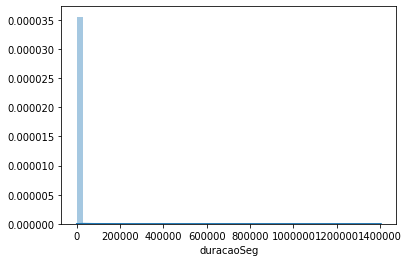

```python
sns.distplot(df['duracaoSeg'])
```

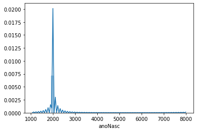

```python
sns.distplot(df['anoNasc'])
```

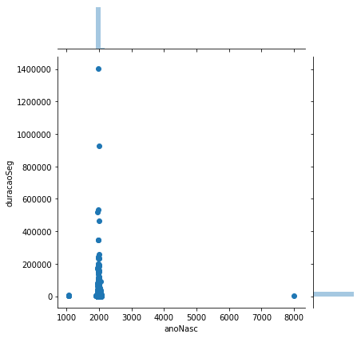

```python
sns.jointplot(x='anoNasc',y='duracaoSeg',data=df)
```

Pela alta variabilidade dos dados, os gráficos ficaram péssimos de ler. Vou tentar retirar os outliers de duração e de ano nascimento.

- Retirando os nascidos antes de 1920 e após 2010.
- Retirando viagens de mais de 12h = 43200 segundos.

```python
df = df.drop(df[df['duracaoSeg']>43200].index)
df = df.drop(df[df['anoNasc']>2010].index)
df = df.drop(df[df['anoNasc']<1920].index)
```

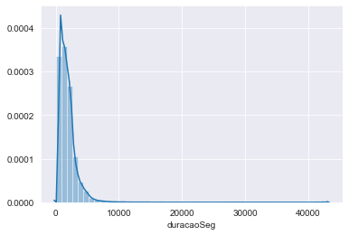

```python
sns.distplot(df['duracaoSeg']);
```

Assim assim ficou uma ruim, mas ja temos a ideia. Vou criar algumas variáveis pra ajudar e nos próximos plots ja sei que vou colocar a escala do eixo X entre 0 e 10800 segundos (3h).

### 3.1 Viagens cirulares

Para enriquecer as análises será criada uma coluna chamada `circular` para indicar se a viagem começou e terminou na mesma estação (`circular`) ou em estações diferentes (`trecho`).

```python
df['circular'] = np.where(df['estacaoInicial']==df['estacaoFinal'], 'Circular', 'Trecho')
circulares = df[df['circular']=='Circular']
trechos = df[df['circular']=='Trecho']

df.head(10)
```

|  | id | duracaoSeg | estacaoInicial | inicioViagem | estacaoFinal | terminoViagem | anoNasc | circular |
| --- | --- | --- | --- | --- | --- | --- | --- | --- |
| 0 | 1019234BikeSSA | 2718 | 8 - Quadras do Rio Vermelho | 2020-01-01 05:08:05 | 2 - Estação Porto da Barra | 2020-01-01 05:53:23 | 1984 | Trecho |
| 1 | 1019236BikeSSA | 1426 | 31 - Fonte do Boi | 2020-01-01 05:30:42 | 4 - Orungan | 2020-01-01 05:54:28 | 1993 | Trecho |
| 2 | 1019237BikeSSA | 989 | 33 - Jardim de Alah | 2020-01-01 05:32:47 | 11 - Amaralina | 2020-01-01 05:49:16 | 1997 | Trecho |
| 3 | 1019238BikeSSA | 2020 | 38 - Piatã | 2020-01-01 05:35:36 | 19 - Pinto de Aguiar (UCSAL) | 2020-01-01 06:09:16 | 1995 | Trecho |
| 4 | 1019239BikeSSA | 1984 | 38 - Piatã | 2020-01-01 05:36:35 | 19 - Pinto de Aguiar (UCSAL) | 2020-01-01 06:09:39 | 1993 | Trecho |
| 5 | 1019240BikeSSA | 758 | 44 - Quartel de Amaralina | 2020-01-01 05:42:39 | 8 - Quadras do Rio Vermelho | 2020-01-01 05:55:17 | 1978 | Trecho |
| 6 | 1019241BikeSSA | 1655 | 25 - Passeo Itaigara | 2020-01-01 05:45:18 | 27 - Praça Ana Lúcia Magalhães | 2020-01-01 06:12:53 | 1950 | Trecho |
| 7 | 1019242BikeSSA | 21190 | 8 - Quadras do Rio Vermelho | 2020-01-01 05:45:37 | 8 - Quadras do Rio Vermelho | 2020-01-01 11:38:47 | 1988 | Circular |
| 8 | 1019244BikeSSA | 685 | 22 - Largo da Graça | 2020-01-01 05:48:33 | 21 - Campo Grande | 2020-01-01 05:59:58 | 1994 | Trecho |
| 9 | 1019245BikeSSA | 538 | 4 - Orungan | 2020-01-01 05:50:19 | 43 - Praça Clériston Andrade | 2020-01-01 05:59:17 | 1998 | Trecho |

#### Quantidade de viagens circulares e de trecho

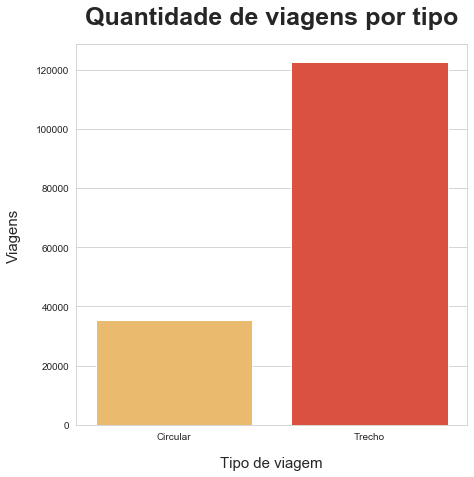

```python
plt.figure(figsize=(7,7))
sns.set_style('whitegrid')
circ = df.groupby(['circular']).count().iloc[:,:1].reset_index()
plot = sns.barplot(x='circular',y='id',data=circ,estimator=sum, palette="YlOrRd")
plot.set_ylabel('Viagens', fontsize=15, labelpad=15)
plot.set_xlabel('Tipo de viagem', fontsize=15, labelpad=15)
plot.set_title('Quantidade de viagens por tipo', fontsize=25, fontweight="bold", pad=20);
```

Quase 3,5 vezes mais viagens entre estações diferentes que circulares.

### Top20 - Estações de viagens cirulares

```python
circulares.groupby(['estacaoInicial']).count().sort_values('id',ascending=False).iloc[:,0:1].reset_index().head(20)
```

|  | estacaoInicial | id |
| --- | --- | --- |
| 0 | 2 - Estação Porto da Barra | 2699 |
| 1 | 33 - Jardim de Alah | 2637 |
| 2 | 45 - Jardim dos Namorados | 2325 |
| 3 | 3 - Barra Professor Lemos Brito | 1947 |
| 4 | 34 - Boca do Rio | 1737 |
| 5 | 23 - Nossa Senhora da Luz | 1683 |
| 6 | 41 - Praça Lord Cochrane | 1484 |
| 7 | 35 - Centro de Convenções | 1238 |
| 8 | 38 - Piatã | 1230 |
| 9 | 8 - Quadras do Rio Vermelho | 1200 |
| 10 | 11 - Amaralina | 1138 |
| 11 | 29 - Praça do Sol | 1130 |
| 12 | 27 - Praça Ana Lúcia Magalhães | 903 |
| 13 | 30 - Centenário | 894 |
| 14 | 36 - Patamares | 883 |
| 15 | 1 - Parque Costa Azul | 838 |
| 16 | 44 - Quartel de Amaralina | 807 |
| 17 | 40 - Imbuí II | 717 |
| 18 | 39 - Itapuã | 662 |
| 19 | 10 - Largo da Mariquita | 638 |

### Top20 - Estações de início de viagens não-circulares

```python
trechos.groupby(['estacaoInicial']).count().sort_values('id',ascending=False).iloc[:,0:1].reset_index().head(20)
```

|  | estacaoInicial | id |
| --- | --- | --- |
| 0 | 2 - Estação Porto da Barra | 8323 |
| 1 | 3 - Barra Professor Lemos Brito | 6198 |
| 2 | 29 - Praça do Sol | 5913 |
| 3 | 8 - Quadras do Rio Vermelho | 5395 |
| 4 | 30 - Centenário | 5111 |
| 5 | 23 - Nossa Senhora da Luz | 4974 |
| 6 | 11 - Amaralina | 4772 |
| 7 | 45 - Jardim dos Namorados | 4648 |
| 8 | 33 - Jardim de Alah | 4637 |
| 9 | 34 - Boca do Rio | 4461 |
| 10 | 41 - Praça Lord Cochrane | 4217 |
| 11 | 10 - Largo da Mariquita | 4167 |
| 12 | 35 - Centro de Convenções | 4081 |
| 13 | 44 - Quartel de Amaralina | 3573 |
| 14 | 31 - Fonte do Boi | 2983 |
| 15 | 38 - Piatã | 2780 |
| 16 | 36 - Patamares | 2687 |
| 17 | 13 - Largo da Piedade | 2525 |
| 18 | 39 - Itapuã | 2252 |
| 19 | 43 - Praça Clériston Andrade | 2213 |

### Top20 - Estações de término de viagens não-circulares

```python
trechos.groupby(['estacaoFinal']).count().sort_values('id',ascending=False).iloc[:,0:1].reset_index().head(20)
```

|  | estacaoFinal | id |
| --- | --- | --- |
| 0 | 2 - Estação Porto da Barra | 11163 |
| 1 | 3 - Barra Professor Lemos Brito | 6966 |
| 2 | 29 - Praça do Sol | 5750 |
| 3 | 8 - Quadras do Rio Vermelho | 5644 |
| 4 | 30 - Centenário | 5458 |
| 5 | 23 - Nossa Senhora da Luz | 4994 |
| 6 | 11 - Amaralina | 4986 |
| 7 | 33 - Jardim de Alah | 4848 |
| 8 | 41 - Praça Lord Cochrane | 4724 |
| 9 | 45 - Jardim dos Namorados | 4629 |
| 10 | 34 - Boca do Rio | 4520 |
| 11 | 10 - Largo da Mariquita | 4101 |
| 12 | 35 - Centro de Convenções | 3795 |
| 13 | 44 - Quartel de Amaralina | 3764 |
| 14 | 31 - Fonte do Boi | 3332 |
| 15 | 38 - Piatã | 2812 |
| 16 | 36 - Patamares | 2547 |
| 17 | 39 - Itapuã | 2359 |
| 18 | 43 - Praça Clériston Andrade | 2313 |
| 19 | 13 - Largo da Piedade | 1882 |

Com exceção de algumas estações no final da lista, observa-se uma grande semelhança entre as estações que mais registraram saídas e as que mais registraram devolvimentos (apenas para viagens não-circulares). Isso pode indicar viagens circulares feitas em duas etapas ou o uso contínuo (como rota de trabalho).

Além disso, observa-se algumas estações recebendo mais do que registrando saída. Apesar de ser uma cenário sem levar em consideração o horário e, com isso, não possibilitar avaliações detalhadas, é algo a se atentar.

Por fim, percebe-se também uma grande predominância das estações em pontos túriscos e orla. Desta forma, a estação do Largo da Piedade chama a atenção por não ser na orla e ao mesmo tempo ser uma região que não possui tanta infraestrutura de ciclofaixas como a Garibaldi (estação Clériston Andrade), que também está na lista mas não é orla.

Estas visualizações podem até confirmar a tendência de uso para esportes e lazer.

#### Diferença entre a duração das viagens circulares e não circulares - histograma/densidade da distribuição

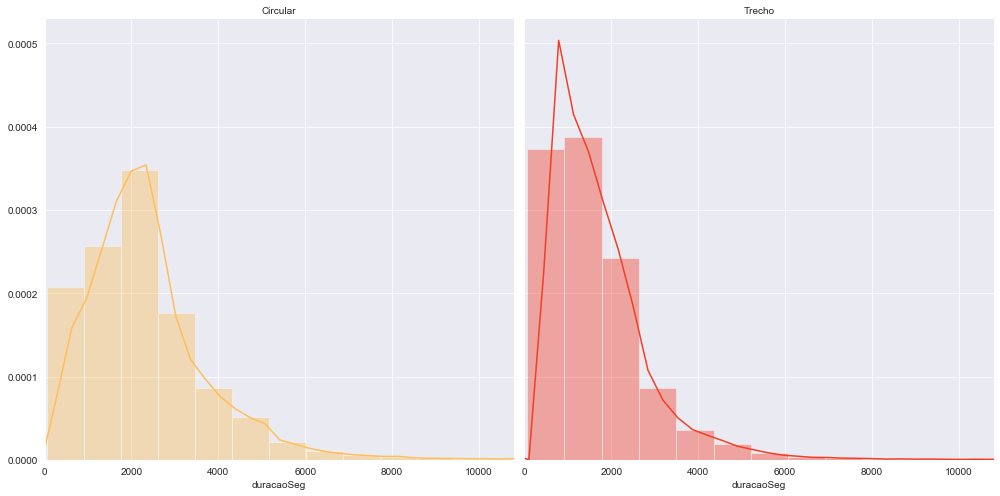

```python
sns.set_style('darkgrid')
g = sns.FacetGrid(data=df, col='circular', height=7, aspect=1, hue='circular', col_order=['Circular', 'Trecho'],
                  palette= 'YlOrRd', hue_order=['Circular', 'Trecho']);
g.map(sns.distplot,'duracaoSeg').set(xlim=(0, 10800));
g.set_titles("{col_name}");
```

Percebe-se que a contagem de viagens circulares são mais deslocadas à direita, mostrando maiores durações, enquanto as de trecho são bastante acentuadas em durações curtas (menos de 2000seg = 33min).

#### Estatísticas sobre as durações das viagens CIRCULARES

```python
df[df['circular']=='Circular']['duracaoSeg'].describe()
```

```
count    35502.000000
mean      2282.311053
std       1888.847318
min         61.000000
25%       1264.250000
50%       2071.000000
75%       2856.000000
max      42572.000000
Name: duracaoSeg, dtype: float64
```

#### Estatísticas sobre as durações das viagens NÃO CIRCULARES

```python
df[df['circular']=='Trecho']['duracaoSeg'].describe()
```

```
count    122420.000000
mean       1626.501315
std        1454.687424
min          61.000000
25%         770.000000
50%        1338.000000
75%        2108.000000
max       42991.000000
Name: duracaoSeg, dtype: float64
```

O que confirma a observação dos histogramas. Existe uma diferença significativa nas durações:

- Viagens que iniciam e terminam na mesma estação duram **em média** 38 minutos, desvio padrão de mediana em 35 minutos.
- Viagens que iniciam e terminam em estações diferentes duram **em média** 27 minutos, mediana em 22,3 minutos.

Além disso, o desvio padrão das viagens circulares é de 31,5 minutos, enquanto das não-circulares 24,2 minutos. Logo, o conjunto das viagens não-circulares é menos disperso, o que pode indicar que são usuários recorrentes que possuem um padrão de uso mais definido que os de viagens circulares (conjunto mais disperso).

### 3.2. Distribuição de idade

Transformando `ano de nascimento` em `idade` para melhorar a abordagem.

```python
df['idade'] = df['anoNasc'].apply(lambda x:2020-x)
```

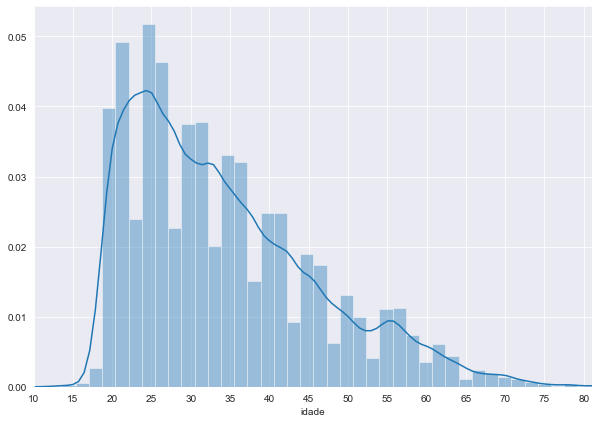

```python
plt.figure(figsize=(10,7))
sns.set_style('darkgrid')
plot = sns.distplot(df['idade'])
plot.set(xlim=(10, 81), xticks=np.arange(10,81,5));
```

#### Diferença entre as idades dos usuários em viagens circulares e não circulares - histograma/densidade da distribuição

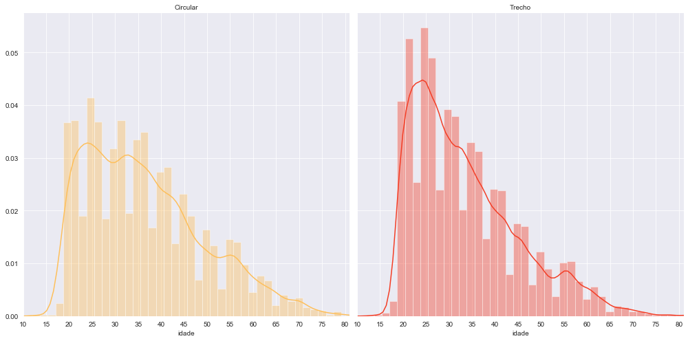

```python
sns.set_style('darkgrid')
g = sns.FacetGrid(data=df, col='circular', height=7, aspect=1, hue='circular', col_order=['Circular', 'Trecho'],
                  palette= 'YlOrRd', hue_order=['Circular', 'Trecho'])
g.map(sns.distplot,'idade').set(xlim=(10, 81), xticks=np.arange(10,81,5))
g.set_titles("{col_name}")
```

Aparentemente os usuários em viagens circulares tem idades mais variadas enquanto os usuários que vão de uma estação a outra estão mais acumulados entre 20 e 35 anos.

#### Estatísticas sobre a idade dos usuários das viagens CIRCULARES

```python
df[df['circular']=='Circular']['idade'].describe()
```

```
count    35502.000000
mean        36.607487
std         12.862276
min         12.000000
25%         26.000000
50%         34.000000
75%         44.000000
max         96.000000
Name: idade, dtype: float64
```

#### Estatísticas sobre a idade dos usuários das viagens NÃO CIRCULARES

```python
df[df['circular']=='Trecho']['idade'].describe()
```

```
count    122420.000000
mean         33.581523
std          11.600069
min          12.000000
25%          24.000000
50%          31.000000
75%          40.000000
max          96.000000
Name: idade, dtype: float64
```

#### Estatísticas sobre a idade de todos os usuários

```python
df['idade'].describe()
```

```
count    157922.000000
mean         34.261781
std          11.962339
min          12.000000
25%          25.000000
50%          32.000000
75%          41.000000
max          96.000000
Name: idade, dtype: float64
```

A hipótese é confirmada, tal qual aparentou no histograma:

- A média de idade dos usuários em viagens circulares é de 36,6 anos, a mediana em 34 anos.
- A média de idade dos usuários em viagens não circulares é de 33,6 anos, a mediana em 31 anos.
- A média de idade geral é de 34,3 anos e mediana em 32 anos.

#### Top 10 idades - Geral

```python
df['idade'].value_counts().head(10)
```

```
24    7152
21    6590
25    6567
22    6457
23    6359
26    6267
28    6027
27    6012
20    5462
33    5317
Name: idade, dtype: int64
```

#### Top 10 idades - Circular

```python
df[df['circular']=='Circular']['idade'].value_counts().head(10)
```

```
24    1298
32    1177
25    1175
33    1164
27    1149
23    1136
21    1134
28    1103
20    1100
19    1095
Name: idade, dtype: int64
```

#### Top 10 idades - Não circular

```python
df[df['circular']=='Trecho']['idade'].value_counts().head(10)
```

```
24    5854
21    5456
25    5392
22    5378
23    5223
26    5214
28    4924
27    4863
20    4362
33    4153
Name: idade, dtype: int64
```

#### Relação (Idade x Duração da Viagem)

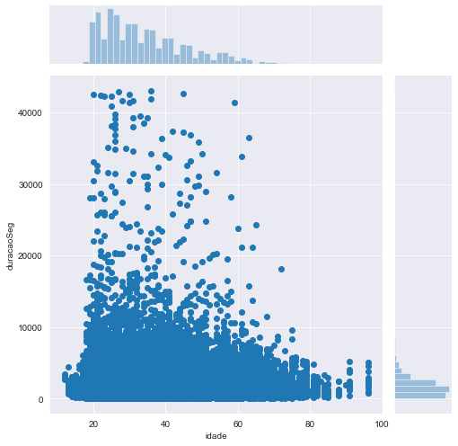

```python
sns.jointplot(x='idade',y='duracaoSeg',data=df, height=7);
```

Praticamente não há relação direta, e coeficiente de correlação de pearson pode quantificar esta proporcionalidade.

```python
df.loc[:,['idade','duracaoSeg']].corr()
```

|  | idade | duracaoSeg |
| --- | --- | --- |
| idade | 1.000000 | 0.046563 |
| duracaoSeg | 0.046563 | 1.000000 |

## 4. Tratamento de dados relacionados a datas

Precisam ser feitas algumas alterações de tipo e formatação para que consigamos visualizar os dados e fazer cálculos com as duas colunas de datas.

```python
df.info()
```

```
<class 'pandas.core.frame.DataFrame'>
Int64Index: 157922 entries, 0 to 37279
Data columns (total 9 columns):
 #   Column          Non-Null Count   Dtype
---  ------          --------------   -----
 0   id              157922 non-null  object
 1   duracaoSeg      157922 non-null  int64
 2   estacaoInicial  157922 non-null  object
 3   inicioViagem    157922 non-null  object
 4   estacaoFinal    157922 non-null  object
 5   terminoViagem   157922 non-null  object
 6   anoNasc         157922 non-null  int64
 7   circular        157922 non-null  object
 8   idade           157922 non-null  int64
dtypes: int64(3), object(6)
memory usage: 12.0+ MB
```

Primeiramente precisamos mudar o tipo das colunas `inicioViagem` e `terminoViagem` para o tipo data.

```python
df['inicioViagem'] = pd.to_datetime(df['inicioViagem'])
df['terminoViagem'] = pd.to_datetime(df['terminoViagem'])
```

```python
df.info()
```

```
<class 'pandas.core.frame.DataFrame'>
Int64Index: 157922 entries, 0 to 37279
Data columns (total 9 columns):
 #   Column          Non-Null Count   Dtype
---  ------          --------------   -----
 0   id              157922 non-null  object
 1   duracaoSeg      157922 non-null  int64
 2   estacaoInicial  157922 non-null  object
 3   inicioViagem    157922 non-null  datetime64[ns]
 4   estacaoFinal    157922 non-null  object
 5   terminoViagem   157922 non-null  datetime64[ns]
 6   anoNasc         157922 non-null  int64
 7   circular        157922 non-null  object
 8   idade           157922 non-null  int64
dtypes: datetime64[ns](2), int64(3), object(4)
memory usage: 12.0+ MB
```

Certo, agora vamos dividir cada coluna de data ente hora, dia, mês e criar uma coluna indicando o dia da semana.

```python
df['mesInicio'] = df['inicioViagem'].dt.month
df['diaInicio'] = df['inicioViagem'].dt.day
df['horaInicio'] = df['inicioViagem'].dt.hour
df['diaSemInicio'] = df['inicioViagem'].apply(lambda x:x.day_name())
df['mesTermino'] = df['terminoViagem'].dt.month
df['diaTermino'] = df['terminoViagem'].dt.month
df['horaTermino'] = df['terminoViagem'].dt.hour
df['diaSemTermino'] = df['terminoViagem'].apply(lambda x:x.day_name())
```

Organizando e traduzinho:

```python
df = df[['id', 'estacaoInicial', 'inicioViagem', 'mesInicio', 'diaInicio','horaInicio','diaSemInicio',
    'estacaoFinal','terminoViagem', 'mesTermino', 'diaTermino','horaTermino','diaSemTermino','duracaoSeg', 'anoNasc', 'idade',
    'circular']]

df = df.replace({'Monday':'Segunda-feira','Tuesday':'Terça-feira','Wednesday':'Quarta-feira','Thursday':'Quinta-feira',
                       'Friday':'Sexta-feira','Saturday':'Sábado','Sunday':'Domingo'})
```

Resultado:

```python
df.head()
```

|  | id | estacaoInicial | inicioViagem | mesInicio | diaInicio | horaInicio | diaSemInicio | estacaoFinal | terminoViagem | mesTermino | diaTermino | horaTermino | diaSemTermino | duracaoSeg | anoNasc | idade | circular |
| --- | --- | --- | --- | --- | --- | --- | --- | --- | --- | --- | --- | --- | --- | --- | --- | --- | --- |
| 0 | 1019234BikeSSA | 8 - Quadras do Rio Vermelho | 2020-01-01 05:08:05 | 1 | 1 | 5 | Quarta-feira | 2 - Estação Porto da Barra | 2020-01-01 05:53:23 | 1 | 1 | 5 | Quarta-feira | 2718 | 1984 | 36 | Trecho |
| 1 | 1019236BikeSSA | 31 - Fonte do Boi | 2020-01-01 05:30:42 | 1 | 1 | 5 | Quarta-feira | 4 - Orungan | 2020-01-01 05:54:28 | 1 | 1 | 5 | Quarta-feira | 1426 | 1993 | 27 | Trecho |
| 2 | 1019237BikeSSA | 33 - Jardim de Alah | 2020-01-01 05:32:47 | 1 | 1 | 5 | Quarta-feira | 11 - Amaralina | 2020-01-01 05:49:16 | 1 | 1 | 5 | Quarta-feira | 989 | 1997 | 23 | Trecho |
| 3 | 1019238BikeSSA | 38 - Piatã | 2020-01-01 05:35:36 | 1 | 1 | 5 | Quarta-feira | 19 - Pinto de Aguiar (UCSAL) | 2020-01-01 06:09:16 | 1 | 1 | 6 | Quarta-feira | 2020 | 1995 | 25 | Trecho |
| 4 | 1019239BikeSSA | 38 - Piatã | 2020-01-01 05:36:35 | 1 | 1 | 5 | Quarta-feira | 19 - Pinto de Aguiar (UCSAL) | 2020-01-01 06:09:39 | 1 | 1 | 6 | Quarta-feira | 1984 | 1993 | 27 | Trecho |

#### Criando uma tabela com a contagem de viagens por dias, horas, meses

Será a base para criação dos gráficos a seguir.

```python
df2 = df.groupby(['horaInicio', 'diaSemInicio', 'mesInicio', 'diaInicio', 'circular']).count().iloc[:,0:1].sort_values('id',ascending=False)
df2.columns = ['cont']
df2 = df2.reset_index()
df2
```

|  | horaInicio | diaSemInicio | mesInicio | diaInicio | circular | cont |
| --- | --- | --- | --- | --- | --- | --- |
| 0 | 18 | Terça-feira | 1 | 28 | Trecho | 268 |
| 1 | 18 | Segunda-feira | 1 | 27 | Trecho | 253 |
| 2 | 18 | Quinta-feira | 1 | 30 | Trecho | 250 |
| 3 | 18 | Segunda-feira | 2 | 3 | Trecho | 248 |
| 4 | 18 | Segunda-feira | 1 | 13 | Trecho | 248 |
| ... | ... | ... | ... | ... | ... | ... |
| 4242 | 22 | Segunda-feira | 3 | 9 | Circular | 1 |
| 4243 | 23 | Quarta-feira | 2 | 19 | Circular | 1 |
| 4244 | 5 | Sábado | 1 | 25 | Circular | 1 |
| 4245 | 23 | Quarta-feira | 2 | 12 | Circular | 1 |
| 4246 | 8 | Quarta-feira | 2 | 19 | Circular | 1 |

4247 rows × 6 columns

## 5. Visualização de dados relacionados à datas

### 5.1. Quantidade de viagens por mês

```python
df['mesInicio'].value_counts()
```

```
1    61056
2    43636
3    36282
7    16948
Name: mesInicio, dtype: int64
```

Observa-se um claro decrescimo, os gráficos a seguir representam os valores. As linhas verticais são os intervalos de confiança da distribuição.

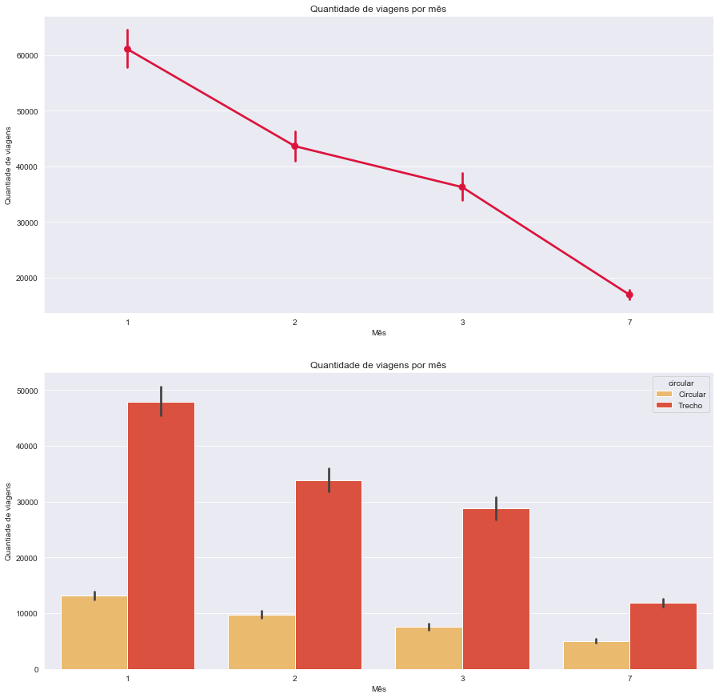

```python
fig,(ax1,ax2)= plt.subplots(nrows=2)
fig.set_size_inches(15,15)


bar1 = sns.pointplot(data=df2, x='mesInicio', y='cont', ax=ax1, estimator=sum, join=True, color='crimson')
ax1.set(xlabel='Mês', ylabel='Quantiade de viagens',
        title="Quantidade de viagens por mês", label='big');

bar1 = sns.barplot(data=df2, x='mesInicio', y='cont', ax=ax2, palette='YlOrRd', estimator=sum, hue='circular',
                  hue_order=[ 'Circular','Trecho'])
ax2.set(xlabel='Mês', ylabel='Quantiade de viagens',
        title="Quantidade de viagens por mês", label='big');
```

### 5.2. Quantidade de viagens por dia

```python
agreg1 = df2.groupby(['mesInicio', 'diaInicio','diaSemInicio']).sum().reset_index().loc[:,['mesInicio','diaInicio','diaSemInicio','cont']]
agregjan = agreg1[agreg1['mesInicio']==1]
agregfev = agreg1[agreg1['mesInicio']==2]
agregmar = agreg1[agreg1['mesInicio']==3]
agregjul = agreg1[agreg1['mesInicio']==7]
```

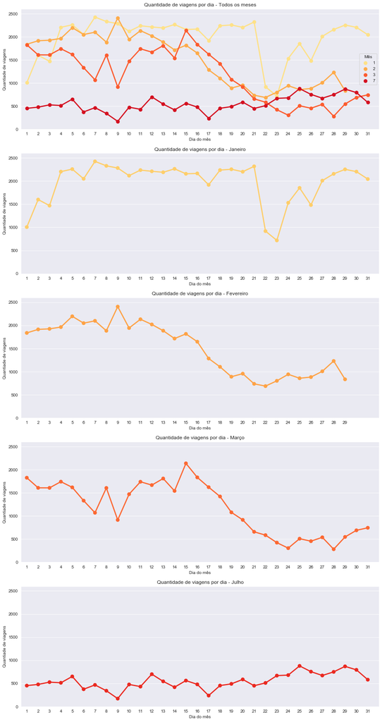

```python
fig,(ax1,ax2,ax3,ax4,ax5)= plt.subplots(nrows=5)
fig.set_size_inches(15,30)

plot1 = sns.pointplot(
    x='diaInicio',y='cont',hue='mesInicio', ci=None, data=df2, estimator=sum, ax=ax1,
    palette='YlOrRd')
ax1.set(xlabel='Dia do mês', ylabel='Quantiade de viagens', xlim=(None,31), ylim=(0, 2600),
        title="Quantidade de viagens por dia - Todos os meses", label='big');
ax1.legend(title="Mês");


plot1 = sns.pointplot(
    x='diaInicio',y='cont', ci=None, data=agregjan, estimator=sum, ax=ax2, color='#fece6a')
ax2.set(xlabel='Dia do mês', ylabel='Quantiade de viagens', xlim=(None,31), ylim=(0, 2600),
        title="Quantidade de viagens por dia - Janeiro", label='big');

plot1 = sns.pointplot(
    x='diaInicio',y='cont', ci=None, data=agregfev, estimator=sum, ax=ax3, color='#fea245')
ax3.set(xlabel='Dia do mês', ylabel='Quantiade de viagens', xlim=(None,31), ylim=(0, 2600),
        title="Quantidade de viagens por dia - Fevereiro", label='big');

plot1 = sns.pointplot(
    x='diaInicio',y='cont', ci=None, data=agregmar, estimator=sum, ax=ax4, color='#fc6832')
ax4.set(xlabel='Dia do mês', ylabel='Quantiade de viagens', xlim=(None,31), ylim=(0, 2600),
        title="Quantidade de viagens por dia - Março", label='big');

plot1 = sns.pointplot(
    x='diaInicio',y='cont', ci=None, data=agregjul, estimator=sum, ax=ax5, color='#ea2920')
ax5.set(xlabel='Dia do mês', ylabel='Quantiade de viagens', xlim=(None,31), ylim=(0, 2600),
        title="Quantidade de viagens por dia - Julho", label='big');
```

### 5.3. Quantidade de viagens por hora

#### Dividido por dia da semana e tipo de viagem

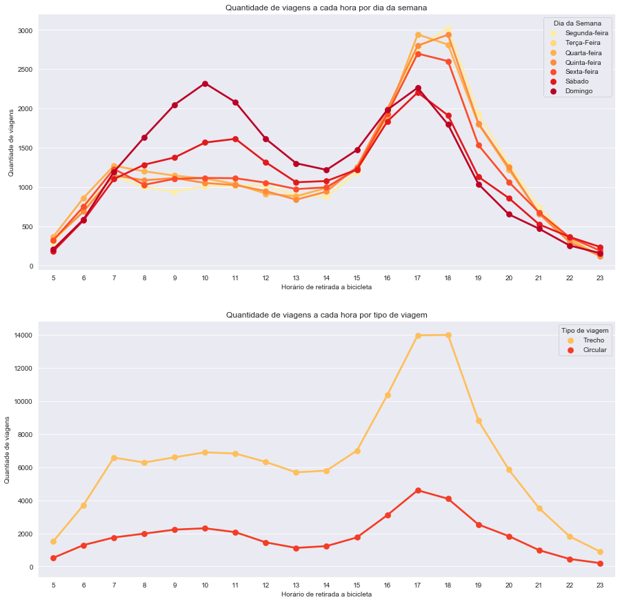

```python
fig,(ax1,ax2)= plt.subplots(nrows=2)
fig.set_size_inches(15,15)

hueOrder = ["Segunda-feira","Terça-Feira","Quarta-feira","Quinta-feira",'Sexta-feira',"Sábado","Domingo"]
plot1 = sns.pointplot(
    x='horaInicio',y='cont',hue='diaSemInicio', ci=None, hue_order=hueOrder, data=df2, estimator=sum, ax=ax1,
    palette='YlOrRd')
ax1.set(xlabel='Horário de retirada a bicicleta', ylabel='Quantiade de viagens',
        title="Quantidade de viagens a cada hora por dia da semana", label='big');
ax1.legend(title="Dia da Semana");

plot2 = sns.pointplot(
    x='horaInicio',y='cont',hue='circular', ci=None, data=df2, estimator=sum, ax=ax2, palette='YlOrRd')
ax2.set(xlabel='Horário de retirada a bicicleta', ylabel='Quantiade de viagens',
        title="Quantidade de viagens a cada hora por tipo de viagem", label='big');
ax2.legend(title="Tipo de viagem");
```

Observa-se um comportamento diferente aos sábados e domingos, com um equilibrio maior entre o meio da manhã e a tarde. Provavelmente causado pelos passeios casuais, esporte e lazer.

No segundo gráfico fica claro (além da menor quantidade ja observada em outros gráficos) nas viagens não-circulares um pico às 7 da manhã e um crescimento consideravelmente maior à 17h e 18h, quando comparado às viagens circulares, provavelmente causado por quem usa para ir e voltar do trabalho.

### 5.4. Quantidade de viagens por dia da semana

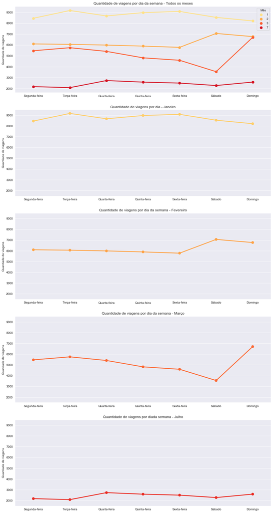

```python
fig,(ax1,ax2,ax3,ax4,ax5)= plt.subplots(nrows=5)
fig.set_size_inches(15,30)
sortOrder = ["Segunda-feira","Terça-feira","Quarta-feira","Quinta-feira",'Sexta-feira',"Sábado","Domingo"]

plot1 = sns.pointplot(x='diaSemInicio',y='cont',hue='mesInicio', ci=None, data=df2, estimator=sum, ax=ax1,
    palette='YlOrRd', order=sortOrder)
ax1.set(xlabel=None, ylabel='Quantiade de viagens',
        title="Quantidade de viagens por dia da semana - Todos os meses", label='big');
ax1.legend(title="Mês");


plot1 = sns.pointplot(x='diaSemInicio',y='cont', ci=None, data=agregjan, estimator=sum, ax=ax2,
                      color='#fece6a', order=sortOrder)
ax2.set(xlabel=None, ylabel='Quantiade de viagens', ylim=(1500, 9500),
        title="Quantidade de viagens por dia - Janeiro", label='big');

plot1 = sns.pointplot(x='diaSemInicio',y='cont', ci=None, data=agregfev, estimator=sum, ax=ax3,
                      color='#fea245', order=sortOrder)
ax3.set(xlabel=None, ylabel='Quantiade de viagens', ylim=(1500, 9500),
        title="Quantidade de viagens por dia da semana - Fevereiro", label='big');

plot1 = sns.pointplot(x='diaSemInicio',y='cont', ci=None, data=agregmar, estimator=sum, ax=ax4,
                      color='#fc6832', order=sortOrder)
ax4.set(xlabel=None, ylabel='Quantiade de viagens', ylim=(1500, 9500),
        title="Quantidade de viagens por dia da semana - Março", label='big');

plot1 = sns.pointplot(x='diaSemInicio',y='cont', ci=None, data=agregjul, estimator=sum, ax=ax5,
                      color='#ea2920', order=sortOrder)
ax5.set(xlabel=None, ylabel='Quantiade de viagens', ylim=(1500, 9500),
        title="Quantidade de viagens por diada semana - Julho", label='big');
```

### 5.5. Quantidade de viagens por dia da semana e por hora - mapa de calor

Criando uma matriz pivotada geral para construção do mapa de calor:

```python
df3 = df2.pivot_table(values='cont', index='diaSemInicio', columns='horaInicio', aggfunc = np.sum, fill_value=0)
df3 = df3.loc[['Segunda-feira', 'Terça-feira', 'Quarta-feira', 'Quinta-feira', 'Sexta-feira', 'Sábado', 'Domingo'], :]
df3
```

| horaInicio diaSemInicio | 5 | 6 | 7 | 8 | 9 | 10 | 11 | 12 | 13 | 14 | 15 | 16 | 17 | 18 | 19 | 20 | 21 | 22 | 23 |
| --- | --- | --- | --- | --- | --- | --- | --- | --- | --- | --- | --- | --- | --- | --- | --- | --- | --- | --- | --- |
| Segunda-feira | 289 | 717 | 1139 | 998 | 939 | 1010 | 1018 | 1013 | 895 | 876 | 1179 | 1897 | 2770 | 3024 | 1932 | 1288 | 739 | 333 | 131 |
| Terça-feira | 342 | 832 | 1258 | 1040 | 1103 | 1040 | 1016 | 919 | 861 | 933 | 1178 | 1922 | 2899 | 3002 | 2104 | 1352 | 773 | 331 | 145 |
| Quarta-feira | 363 | 860 | 1269 | 1199 | 1144 | 1106 | 1038 | 914 | 881 | 987 | 1222 | 1906 | 2943 | 2812 | 1801 | 1221 | 664 | 333 | 128 |
| Quinta-feira | 325 | 686 | 1148 | 1085 | 1113 | 1050 | 1023 | 947 | 837 | 941 | 1256 | 1988 | 2800 | 2939 | 1810 | 1250 | 656 | 297 | 120 |
| Sexta-feira | 318 | 748 | 1229 | 1027 | 1103 | 1114 | 1111 | 1054 | 973 | 994 | 1231 | 1931 | 2698 | 2602 | 1533 | 1063 | 673 | 358 | 189 |
| Sábado | 178 | 574 | 1099 | 1283 | 1375 | 1565 | 1612 | 1314 | 1059 | 1075 | 1221 | 1833 | 2203 | 1911 | 1129 | 858 | 522 | 363 | 236 |
| Domingo | 204 | 585 | 1190 | 1633 | 2048 | 2320 | 2080 | 1612 | 1301 | 1217 | 1470 | 1982 | 2263 | 1794 | 1036 | 651 | 467 | 254 | 157 |

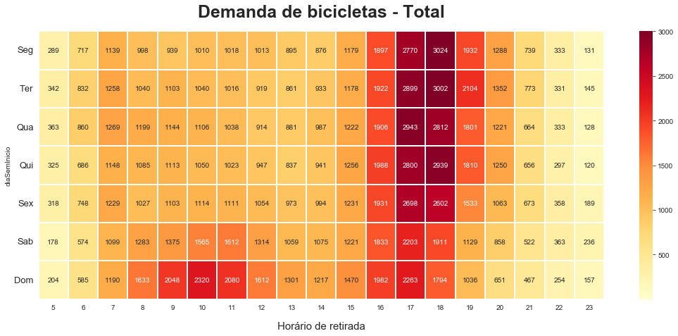

```python
plt.figure(figsize=(18,7))
plot = sns.heatmap(df3,cmap='YlOrRd',linewidth=1, linecolor="white", vmin=1, vmax=3000, annot=True, fmt ='.0f')
plot.set_xlabel('Horário de retirada', fontsize=15, labelpad=15)
plot.set_title('Demanda de bicicletas - Total', fontsize=25, fontweight="bold", pad=20)
plt.yticks(np.arange(7)+0.5,('Seg','Ter','Qua','Qui','Sex','Sab','Dom'), rotation=0, fontsize="13", va="center");
```

Matrizes pivotadas para cada mês

```python
df2janeiro = df2[df2['mesInicio'] == 1]
df2fevereiro = df2[df2['mesInicio'] == 2]
df2marco = df2[df2['mesInicio'] == 3]
df2julho = df2[df2['mesInicio'] == 7]

df3janeiro = df2janeiro.pivot_table(values='cont', index='diaSemInicio', columns='horaInicio', aggfunc = np.sum, fill_value=0)
df3fevereiro = df2fevereiro.pivot_table(values='cont', index='diaSemInicio', columns='horaInicio', aggfunc = np.sum, fill_value=0)
df3marco = df2marco.pivot_table(values='cont', index='diaSemInicio', columns='horaInicio', aggfunc = np.sum, fill_value=0)
df3julho = df2julho.pivot_table(values='cont', index='diaSemInicio', columns='horaInicio', aggfunc = np.sum, fill_value=0)

df3janeiro = df3janeiro.loc[['Segunda-feira', 'Terça-feira', 'Quarta-feira', 'Quinta-feira', 'Sexta-feira', 'Sábado', 'Domingo'], :]
df3fevereiro = df3fevereiro.loc[['Segunda-feira', 'Terça-feira', 'Quarta-feira', 'Quinta-feira', 'Sexta-feira', 'Sábado', 'Domingo'], :]
df3marco = df3marco.loc[['Segunda-feira', 'Terça-feira', 'Quarta-feira', 'Quinta-feira', 'Sexta-feira', 'Sábado', 'Domingo'], :]
df3julho = df3julho.loc[['Segunda-feira', 'Terça-feira', 'Quarta-feira', 'Quinta-feira', 'Sexta-feira', 'Sábado', 'Domingo'], :]
```

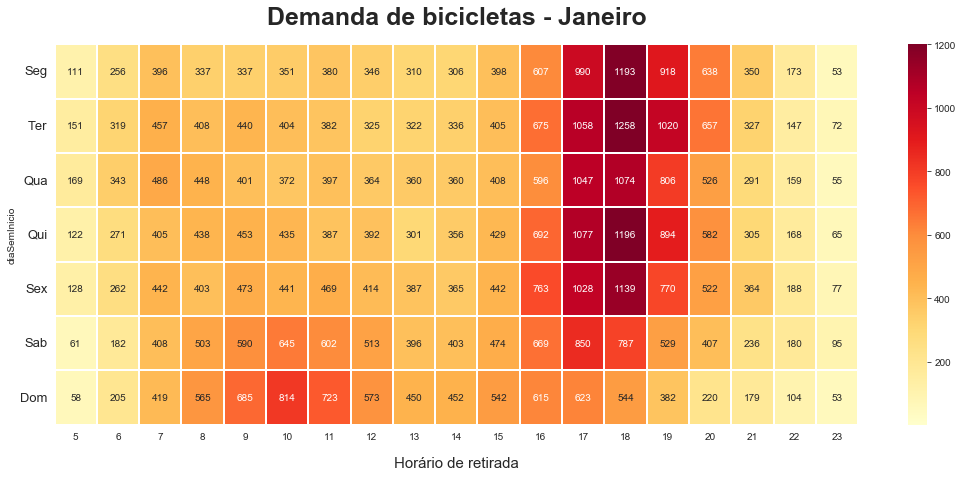

```python
plt.figure(figsize=(18,7))
plot = sns.heatmap(df3janeiro,cmap='YlOrRd',linewidth=1, linecolor="white", vmin=1, vmax=1200, annot=True, fmt ='.0f')
plot.set_xlabel('Horário de retirada', fontsize=15, labelpad=15)
plot.set_title('Demanda de bicicletas - Janeiro', fontsize=25, fontweight="bold", pad=20)
plt.yticks(np.arange(7)+0.5,('Seg','Ter','Qua','Qui','Sex','Sab','Dom'), rotation=0, fontsize="13", va="center");
```

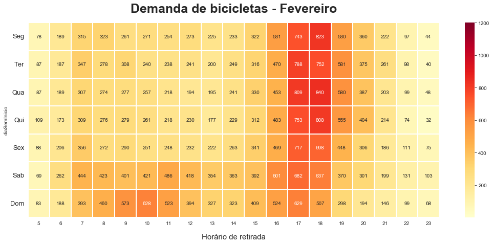

```python
plt.figure(figsize=(18,7))
plot = sns.heatmap(df3fevereiro,cmap='YlOrRd',linewidth=1, linecolor="white", vmin=1, vmax=1200, annot=True, fmt ='.0f')
plot.set_xlabel('Horário de retirada', fontsize=15, labelpad=15)
plot.set_title('Demanda de bicicletas - Fevereiro', fontsize=25, fontweight="bold", pad=20)
plt.yticks(np.arange(7)+0.5,('Seg','Ter','Qua','Qui','Sex','Sab','Dom'), rotation=0, fontsize="13", va="center");
```

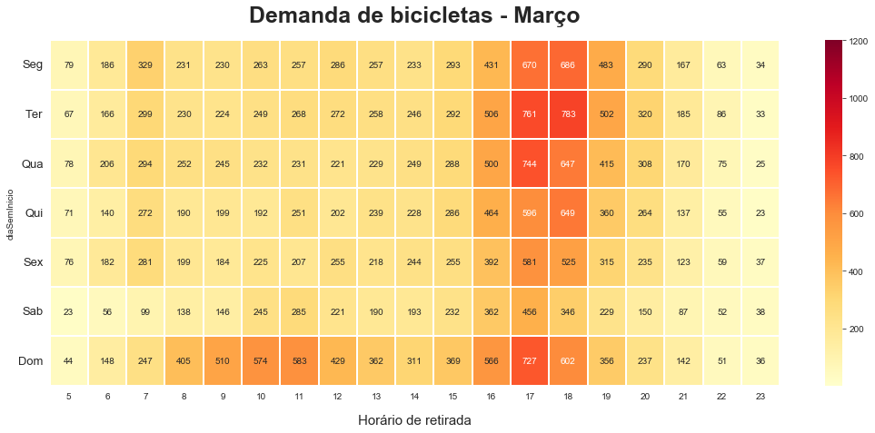

```python
plt.figure(figsize=(18,7))
plot = sns.heatmap(df3marco,cmap='YlOrRd',linewidth=1, linecolor="white", vmin=1, vmax=1200, annot=True, fmt ='.0f')
plot.set_xlabel('Horário de retirada', fontsize=15, labelpad=15)
plot.set_title('Demanda de bicicletas - Março', fontsize=25, fontweight="bold", pad=20)
plt.yticks(np.arange(7)+0.5,('Seg','Ter','Qua','Qui','Sex','Sab','Dom'), rotation=0, fontsize="13", va="center");
```

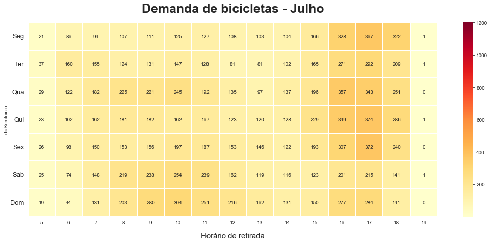

```python
plt.figure(figsize=(18,7))
plot = sns.heatmap(df3julho,cmap='YlOrRd',linewidth=1, linecolor="white", vmin=1, vmax=1200, annot=True, fmt ='.0f')
plot.set_xlabel('Horário de retirada', fontsize=15, labelpad=15)
plot.set_title('Demanda de bicicletas - Julho', fontsize=25, fontweight="bold", pad=20)
plt.yticks(np.arange(7)+0.5,('Seg','Ter','Qua','Qui','Sex','Sab','Dom'), rotation=0, fontsize="13", va="center");
```

## 6. Visualização de dados relacionados à rotas

#### Contagem de rotas

```python
principaisrotas = df.groupby(['estacaoInicial','estacaoFinal']).count().sort_values('id',ascending=False).iloc[:,0:1]
principaisrotas = principaisrotas.reset_index()
```

```python
principaisrotas['rota'] = principaisrotas[['estacaoInicial','estacaoFinal']].agg(' até '.join, axis=1)
principaisrotas = principaisrotas.loc[:,['rota','id','estacaoInicial','estacaoFinal']]
principaisrotas = principaisrotas.rename(columns={'id':'viagens'})
principaisrotas['circular'] = np.where(principaisrotas['estacaoInicial']==principaisrotas['estacaoFinal'], 'Circular', 'Trecho')
principaisrotas
```

|  | rota | viagens | estacaoInicial | estacaoFinal | circular |
| --- | --- | --- | --- | --- | --- |
| 0 | 2 - Estação Porto da Barra até 2 - Estação Por... | 2699 | 2 - Estação Porto da Barra | 2 - Estação Porto da Barra | Circular |
| 1 | 33 - Jardim de Alah até 33 - Jardim de Alah | 2637 | 33 - Jardim de Alah | 33 - Jardim de Alah | Circular |
| 2 | 45 - Jardim dos Namorados até 45 - Jardim dos ... | 2325 | 45 - Jardim dos Namorados | 45 - Jardim dos Namorados | Circular |
| 3 | 3 - Barra Professor Lemos Brito até 3 - Barra ... | 1947 | 3 - Barra Professor Lemos Brito | 3 - Barra Professor Lemos Brito | Circular |
| 4 | 34 - Boca do Rio até 34 - Boca do Rio | 1737 | 34 - Boca do Rio | 34 - Boca do Rio | Circular |
| ... | ... | ... | ... | ... | ... |
| 2180 | 26 - Praça Aquarius até 7 - UFBA Portão 01 | 1 | 26 - Praça Aquarius | 7 - UFBA Portão 01 | Trecho |
| 2181 | 13 - Largo da Piedade até 4 - Praça Orungan | 1 | 13 - Largo da Piedade | 4 - Praça Orungan | Trecho |
| 2182 | 26 - Praça Aquarius até Placeholder 28 - Imbuí I | 1 | 26 - Praça Aquarius | Placeholder 28 - Imbuí I | Trecho |
| 2183 | 27 - Praça Ana Lúcia Magalhães até 22 - Largo ... | 1 | 27 - Praça Ana Lúcia Magalhães | 22 - Largo da Graça | Trecho |
| 2184 | 36 - Patamares até 7 - UFBA Portão 01 | 1 | 36 - Patamares | 7 - UFBA Portão 01 | Trecho |

2185 rows × 5 columns

### TOP 20 Rotas

```python
top20 = principaisrotas.head(20)
top20
```

|  | rota | viagens | estacaoInicial | estacaoFinal | circular |
| --- | --- | --- | --- | --- | --- |
| 0 | 2 - Estação Porto da Barra até 2 - Estação Por... | 2699 | 2 - Estação Porto da Barra | 2 - Estação Porto da Barra | Circular |
| 1 | 33 - Jardim de Alah até 33 - Jardim de Alah | 2637 | 33 - Jardim de Alah | 33 - Jardim de Alah | Circular |
| 2 | 45 - Jardim dos Namorados até 45 - Jardim dos ... | 2325 | 45 - Jardim dos Namorados | 45 - Jardim dos Namorados | Circular |
| 3 | 3 - Barra Professor Lemos Brito até 3 - Barra ... | 1947 | 3 - Barra Professor Lemos Brito | 3 - Barra Professor Lemos Brito | Circular |
| 4 | 34 - Boca do Rio até 34 - Boca do Rio | 1737 | 34 - Boca do Rio | 34 - Boca do Rio | Circular |
| 5 | 23 - Nossa Senhora da Luz até 23 - Nossa Senho... | 1683 | 23 - Nossa Senhora da Luz | 23 - Nossa Senhora da Luz | Circular |
| 6 | 2 - Estação Porto da Barra até 3 - Barra Profe... | 1578 | 2 - Estação Porto da Barra | 3 - Barra Professor Lemos Brito | Trecho |
| 7 | 3 - Barra Professor Lemos Brito até 2 - Estaçã... | 1571 | 3 - Barra Professor Lemos Brito | 2 - Estação Porto da Barra | Trecho |
| 8 | 41 - Praça Lord Cochrane até 41 - Praça Lord C... | 1484 | 41 - Praça Lord Cochrane | 41 - Praça Lord Cochrane | Circular |
| 9 | 35 - Centro de Convenções até 35 - Centro de C... | 1238 | 35 - Centro de Convenções | 35 - Centro de Convenções | Circular |
| 10 | 38 - Piatã até 38 - Piatã | 1230 | 38 - Piatã | 38 - Piatã | Circular |
| 11 | 8 - Quadras do Rio Vermelho até 8 - Quadras do... | 1200 | 8 - Quadras do Rio Vermelho | 8 - Quadras do Rio Vermelho | Circular |
| 12 | 11 - Amaralina até 11 - Amaralina | 1138 | 11 - Amaralina | 11 - Amaralina | Circular |
| 13 | 29 - Praça do Sol até 29 - Praça do Sol | 1130 | 29 - Praça do Sol | 29 - Praça do Sol | Circular |
| 14 | 8 - Quadras do Rio Vermelho até 2 - Estação Po... | 1128 | 8 - Quadras do Rio Vermelho | 2 - Estação Porto da Barra | Trecho |
| 15 | 29 - Praça do Sol até 2 - Estação Porto da Barra | 1112 | 29 - Praça do Sol | 2 - Estação Porto da Barra | Trecho |
| 16 | 27 - Praça Ana Lúcia Magalhães até 27 - Praça ... | 903 | 27 - Praça Ana Lúcia Magalhães | 27 - Praça Ana Lúcia Magalhães | Circular |
| 17 | 30 - Centenário até 30 - Centenário | 894 | 30 - Centenário | 30 - Centenário | Circular |
| 18 | 30 - Centenário até 2 - Estação Porto da Barra | 885 | 30 - Centenário | 2 - Estação Porto da Barra | Trecho |
| 19 | 36 - Patamares até 36 - Patamares | 883 | 36 - Patamares | 36 - Patamares | Circular |

### TOP 20 Rotas divididas por tipo

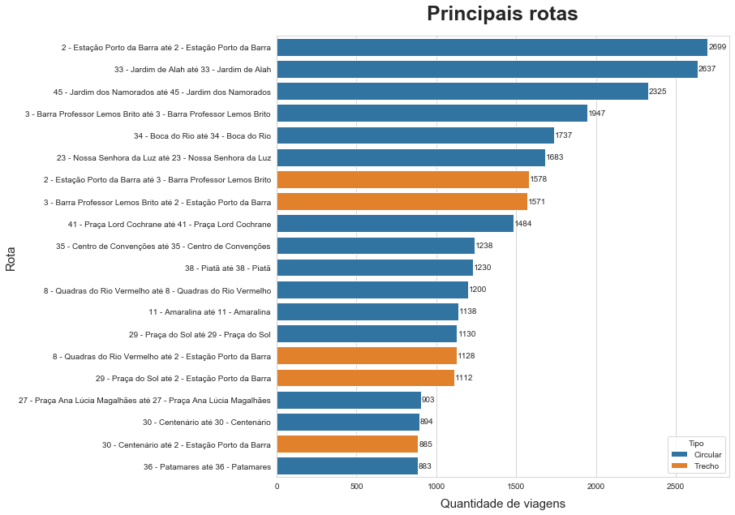

```python
plt.figure(figsize=(10,10))
sns.set_style('whitegrid')
plot = sns.barplot(x='viagens',y='rota',data=top20,hue='circular',dodge=False)
plot.set_xlabel('Quantidade de viagens', fontsize=15, labelpad=10)
plot.set_ylabel('Rota', fontsize=15, labelpad=2);
plot.set_title('Principais rotas', fontsize=25, fontweight="bold", pad=20);
plot.legend(title="Tipo");


for p in plot.patches:
    plot.annotate("%.0f" % p.get_width(), xy=(p.get_width(), p.get_y()+p.get_height()/2),
            xytext=(1, 0), textcoords='offset points', ha="left", va="center")
```

## 7. Mapa - Localização das estações

```python
estacoes1 = pd.read_csv('C:/Users/vlcal/Downloads/Estações_Tembici_Nov2019.csv',sep=';')
estacoes1.head()
```

|  | NUMERO | LAT | LONG |
| --- | --- | --- | --- |
| 0 | 1 | -12.997850 | -38.448834 |
| 1 | 2 | -13.003387 | -38.532712 |
| 2 | 3 | -13.009528 | -38.528098 |
| 3 | 4 | -13.007932 | -38.518877 |
| 4 | 5 | -13.004755 | -38.517843 |

```python
m_1 = folium.Map(location=[-12.97,-38.43], tiles='cartodbpositron', zoom_start=12)

HeatMap(data=estacoes1[['LAT', 'LONG']], radius=18).add_to(m_1)

m_1
```

Make this Notebook Trusted to load map: File -> Trust Notebook

[interactive chart not shown]